# gibberish

## Gibberish detection using autoencoders

I have wanted to play around with autoencoders for anomaly detection for a while. The concept of gibberish detection seems like a good toy example to work with.

Given a sentence can we detect weather it is a real sentence or if it is randomly generated?

Disclaimer: the main object of this is to experiment with autoencoders so other aspects may not be particularly rigoruous.

```python
import pandas as pd
import numpy as np
from matplotlib import pyplot as plt
```

### Part 1:

We will need a dataset consisting of real sentences and randomly generated sentences.

For the real sentences we will use the dataset here: https://github.com/google-research-datasets/wiki-split

"One million English sentences, each split into two sentences that together preserve the original meaning, extracted from Wikipedia edits."

```python
#!wget https://github.com/google-research-datasets/wiki-split/raw/master/train.tsv.zip
#!unzip train.tsv.zip
```

```python
import re
data = pd.read_csv('train.tsv', sep='\t', header=None, usecols=[1])
print(data.iloc[0, 0])
print(data.iloc[0, 0].split("<::::>", 1)[0])
data.iloc[:, 0] = data.iloc[:, 0].apply(lambda x: x.split("<::::>", 1)[0])
data.iloc[:, 0] = data.iloc[:, 0].apply(lambda x: re.sub(r'[^A-Za-z ]+', '', x))
data.iloc[:, 0] = data.iloc[:, 0].apply(lambda x: ' '.join(x.split()))
data.iloc[:, 0] = data.iloc[:, 0].apply(lambda x: x.lower())
```

```
' '' As she translates from one language to another , she tries to find the appropriate wording and context in English that would correspond to the work in Spanish . <::::> Ergo , her poems and stories started to have differing meanings in their respective languages .
' '' As she translates from one language to another , she tries to find the appropriate wording and context in English that would correspond to the work in Spanish .
```

In order to generate gibberish sentences that might pass for real sentences we will generate strings of words such that the distribution of the length of the string is the same as the real sentences and with the same word frequency as an English sentence.

First we look at the lengths of the sentences in out dataset of real sentences and plot the distribution:

```python
data['n_words'] = data.iloc[:,0].apply(lambda x: len(x.split()))
data.head()
```

|  | 1 | n_words |
| --- | --- | --- |
| 0 | as she translates from one language to another... | 27 |
| 1 | bdsm is solely based on consensual activities ... | 14 |
| 2 | critics criticized the use of the disputed fig... | 11 |
| 3 | do re mi is a song by kurt cobain lead singer ... | 19 |
| 4 | for robert price docetism together with encrat... | 21 |

```python
n_rows = 10000
```

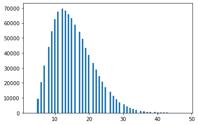

```python
plt.hist(data['n_words'], bins = 100)
plt.show()
```

Looks like a beta distribution so lets try and fit the coefficients:

```python
import scipy.stats as stats
alpha, beta, loc, scale = stats.beta.fit(data['n_words']);
```

```python
[alpha, beta, loc, scale]
```

```
[3.598056313331748, 24.90734041811122, 2.994900250150349, 98.24151471152581]
```

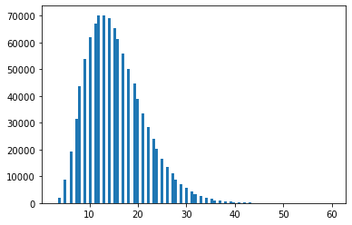

```python
plt.hist(list(map(round, stats.beta.rvs(alpha, beta, loc, scale, size=1000000))), bins = 100)
plt.show()
```

Then above we draw some values from the fitted distribution and plot the histogram, close enough, so looks like the fitted values are ok.

Next we need a dataset of english words and their reletive frequencies. A suitable dataset was found here: https://www.kaggle.com/rtatman/english-word-frequency/data

We then convert the relative frequencies to probabilities.

```python
words = pd.read_csv('unigram_freq.csv')
words['p'] = words['count']/(words['count'].sum())
np.random.choice(words['word'], 10, p=words['p']) #output 10 random words to check it's working
```

```
array(['hours', 'decision', 'tell', 'personally', 'all', 'around', 'may',
       'adult', 'ken', 'council'], dtype=object)
```

Now with the distribution from which to draw our sentence lengths and the probabilities for each word we can generate a dataset of gibberish sentences which have similar statistical characteristics to our real sentences.

We now have our dataset which we will use to train and test our gibberish detection models.

```python
n_words = stats.beta.rvs(alpha, beta, loc=loc, scale=scale, size=n_rows)
n_words = [round(x) for x in n_words]
gib = pd.DataFrame(n_words, columns=['n_words'])
gib['sentence'] = gib['n_words'].apply(lambda x: np.random.choice(words['word'], int(x), p=words['p']))
gib['sentence'] = gib['sentence'].apply(lambda x: ' '.join([str(y) for y in x]))
gib.head()
```

|  | n_words | sentence |
| --- | --- | --- |
| 0 | 22.0 | user unpatched tsb an of monday of week change... |
| 1 | 25.0 | or are together continues level jul owner time... |
| 2 | 11.0 | aja around for a papers could and gcse by the in |
| 3 | 14.0 | lawn best ali introduced lists bs do and and a... |
| 4 | 12.0 | overdose thread stephen readers beginning cana... |

```python
t_df = pd.DataFrame({'sentence':data.sample(frac=1).head(n_rows).iloc[:,0], 'label':[1]*n_rows})
t_df.head()
f_df = pd.DataFrame({'sentence':gib['sentence'], 'label':[0]*n_rows})
f_df.head()
```

|  | sentence | label |
| --- | --- | --- |
| 0 | user unpatched tsb an of monday of week change... | 0 |
| 1 | or are together continues level jul owner time... | 0 |
| 2 | aja around for a papers could and gcse by the in | 0 |
| 3 | lawn best ali introduced lists bs do and and a... | 0 |
| 4 | overdose thread stephen readers beginning cana... | 0 |

```python
df = pd.concat([t_df, f_df]).sample(frac=1).reset_index(drop=True)
df.head()
```

|  | sentence | label |
| --- | --- | --- |
| 0 | hon segundito montilla was the first municipal... | 1 |
| 1 | san these series building learning the where t... | 0 |
| 2 | of this with used does enmore and at local gra... | 0 |
| 3 | day clear designs of to a phaeochromocytoma wa... | 0 |
| 4 | answer user requirements clive their to d elec... | 0 |

```python
#do the standard train test split stuff...

from sklearn.model_selection import train_test_split

train_df, test_df = train_test_split(df, test_size=0.2)
```

```python
train_text = train_df['sentence'].tolist()
train_text = [' '.join(t.split()[0:150]) for t in train_text]
train_text = np.array(train_text, dtype=object)[:, np.newaxis]
train_label = train_df['label'].tolist()

test_text = test_df['sentence'].tolist()
test_text = [' '.join(t.split()[0:150]) for t in test_text]
test_text = np.array(test_text, dtype=object)[:, np.newaxis]
test_label = test_df['label'].tolist()
```

### Part 2:

Before building an autoencoder lets build a simple supervised binary classier to serve as a benchmark. But for both models we will first use the pre-trained ELMo model to create embeddings from our sentences. These embeddings map each sentence to a vector of length 1024 of values between 0 and 1.

Tensorflow 2 seems to break the code use !pip install tensorflow==1.15 !pip install "tensorflow_hub>=0.6.0"

```python
import tensorflow_hub as hub
from tensorflow.keras import backend as K
import tensorflow as tf
import keras.layers as layers
from tensorflow.keras import Input
from tensorflow.keras.models import Model, load_model
from tensorflow.keras.layers import Layer, Dense, Lambda
```

```python
print(tf.__version__)
```

```
1.15.0
```

```python
embed = hub.Module("https://tfhub.dev/google/elmo/3", trainable=False)
def ELMoEmbedding(x):
    return embed(tf.squeeze(tf.cast(x, tf.string)), signature="default", as_dict=True)["default"]
```

```python
input_text = Input(shape=(1,), dtype="string")
embedding = Lambda(ELMoEmbedding, output_shape=(1024, ))(input_text)
dense = Dense(256, activation='relu')(embedding)
pred = Dense(1, activation='sigmoid')(dense)
model = Model(inputs=[input_text], outputs=pred)
model.compile(loss='binary_crossentropy', optimizer='adam', metrics=['accuracy'])
model.summary()
```

```
INFO:tensorflow:Saver not created because there are no variables in the graph to restore
```

```
INFO:tensorflow:Saver not created because there are no variables in the graph to restore
```

[output not shown]

[output not shown]

[output not shown]

[output not shown]

```
Model: "model"
_________________________________________________________________
Layer (type)                 Output Shape              Param #
=================================================================
input_1 (InputLayer)         [(None, 1)]               0
_________________________________________________________________
lambda (Lambda)              (None, 1024)              0
_________________________________________________________________
dense (Dense)                (None, 256)               262400
_________________________________________________________________
dense_1 (Dense)              (None, 1)                 257
=================================================================
Total params: 262,657
Trainable params: 262,657
Non-trainable params: 0
_________________________________________________________________
```

Now lets try training the model

```python
with tf.Session() as session:
    K.set_session(session)
    session.run(tf.global_variables_initializer())
    session.run(tf.tables_initializer())
    model.fit(train_text, train_label, validation_data=(test_text, test_label), epochs=5, batch_size=32)
    #history = model.fit(X, y, epochs=5, batch_size=256, validation_split = 0.2)
```

```
Train on 16000 samples, validate on 4000 samples
```